# EasyVisa Project

## Context:

Business communities in the United States are facing high demand for human resources, but one of the constant challenges is identifying and attracting the right talent, which is perhaps the most important element in remaining competitive. Companies in the United States look for hard-working, talented, and qualified individuals both locally as well as abroad.

The Immigration and Nationality Act (INA) of the US permits foreign workers to come to the United States to work on either a temporary or permanent basis. The act also protects US workers against adverse impacts on their wages or working conditions by ensuring US employers' compliance with statutory requirements when they hire foreign workers to fill workforce shortages. The immigration programs are administered by the Office of Foreign Labor Certification (OFLC).

OFLC processes job certification applications for employers seeking to bring foreign workers into the United States and grants certifications in those cases where employers can demonstrate that there are not sufficient US workers available to perform the work at wages that meet or exceed the wage paid for the occupation in the area of intended employment.

## Objective:

In FY 2016, the OFLC processed 775,979 employer applications for 1,699,957 positions for temporary and permanent labor certifications. This was a nine percent increase in the overall number of processed applications from the previous year. The process of reviewing every case is becoming a tedious task as the number of applicants is increasing every year.

The increasing number of applicants every year calls for a Machine Learning based solution that can help in shortlisting the candidates having higher chances of VISA approval. OFLC has hired your firm EasyVisa for data-driven solutions. You as a data scientist have to analyze the data provided and, with the help of a classification model:

- Facilitate the process of visa approvals.
- Recommend a suitable profile for the applicants for whom the visa should be certified or denied based on the drivers that significantly influence the case status.

## Data Description

The data contains the different attributes of the employee and the employer. The detailed data dictionary is given below.

- case_id: ID of each visa application
- continent: Information of continent the employee
- education_of_employee: Information of education of the employee
- has_job_experience: Does the employee has any job experience? Y= Yes; N = No
- requires_job_training: Does the employee require any job training? Y = Yes; N = No
- no_of_employees: Number of employees in the employer's company
- yr_of_estab: Year in which the employer's company was established
- region_of_employment: Information of foreign worker's intended region of employment in the US.
- prevailing_wage: Average wage paid to similarly employed workers in a specific occupation in the area of intended employment. The purpose of the prevailing wage is to ensure that the foreign worker is not underpaid compared to other workers offering the same or similar service in the same area of employment.
- unit_of_wage: Unit of prevailing wage. Values include Hourly, Weekly, Monthly, and Yearly.
- full_time_position: Is the position of work full-time? Y = Full Time Position; N = Part Time Position
- case_status: Flag indicating if the Visa was certified or denied

## Importing necessary libraries and data

```python
#data manipulation
import numpy as np
import pandas as pd

#data visualization
import seaborn as sns
import matplotlib.pyplot as plt

#statistics
import scipy.stats as stats

#splitting data
from sklearn.model_selection import train_test_split

#creating decision tree
from sklearn.tree import DecisionTreeClassifier
from sklearn import tree

#ensemble classifiers
from sklearn.ensemble import BaggingClassifier
from sklearn.ensemble import RandomForestClassifier
from sklearn.ensemble import AdaBoostClassifier
from sklearn.ensemble import GradientBoostingClassifier
from sklearn.ensemble import StackingClassifier
!pip install xgboost
from xgboost import XGBClassifier

#tuning hyperparameters
from sklearn.model_selection import GridSearchCV

#performance metrics
from sklearn import metrics
from sklearn.metrics import (precision_score, recall_score, f1_score, accuracy_score, confusion_matrix, roc_auc_score)

#ignoring warnings
import warnings
warnings.filterwarnings('ignore')
```

```python
#storing data from csv file into visa variable
visa = pd.read_csv('EasyVisa.csv')
```

## Data Overview

```python
#first 5 rows of visa
visa.head()
```

|  | case_id | continent | education_of_employee | has_job_experience | requires_job_training | no_of_employees | yr_of_estab | region_of_employment | prevailing_wage | unit_of_wage | full_time_position | case_status |
| --- | --- | --- | --- | --- | --- | --- | --- | --- | --- | --- | --- | --- |
| 0 | EZYV01 | Asia | High School | N | N | 14513 | 2007 | West | 592.2029 | Hour | Y | Denied |
| 1 | EZYV02 | Asia | Master's | Y | N | 2412 | 2002 | Northeast | 83425.6500 | Year | Y | Certified |
| 2 | EZYV03 | Asia | Bachelor's | N | Y | 44444 | 2008 | West | 122996.8600 | Year | Y | Denied |
| 3 | EZYV04 | Asia | Bachelor's | N | N | 98 | 1897 | West | 83434.0300 | Year | Y | Denied |
| 4 | EZYV05 | Africa | Master's | Y | N | 1082 | 2005 | South | 149907.3900 | Year | Y | Certified |

```python
#last 5 rows of visa
visa.tail()
```

|  | case_id | continent | education_of_employee | has_job_experience | requires_job_training | no_of_employees | yr_of_estab | region_of_employment | prevailing_wage | unit_of_wage | full_time_position | case_status |
| --- | --- | --- | --- | --- | --- | --- | --- | --- | --- | --- | --- | --- |
| 25475 | EZYV25476 | Asia | Bachelor's | Y | Y | 2601 | 2008 | South | 77092.57 | Year | Y | Certified |
| 25476 | EZYV25477 | Asia | High School | Y | N | 3274 | 2006 | Northeast | 279174.79 | Year | Y | Certified |
| 25477 | EZYV25478 | Asia | Master's | Y | N | 1121 | 1910 | South | 146298.85 | Year | N | Certified |
| 25478 | EZYV25479 | Asia | Master's | Y | Y | 1918 | 1887 | West | 86154.77 | Year | Y | Certified |
| 25479 | EZYV25480 | Asia | Bachelor's | Y | N | 3195 | 1960 | Midwest | 70876.91 | Year | Y | Certified |

#### Observations:

- Each row represents an employee's information.
- Each candidate has a unique case ID.

```python
#number of rows and columns in visa
visa.shape
```

```
(25480, 12)
```

#### Observations:

There are 25,480 rows and 12 columns in visa.

```python
#datatypes and further information about each column in visa
visa.info()
```

```
<class 'pandas.core.frame.DataFrame'>
RangeIndex: 25480 entries, 0 to 25479
Data columns (total 12 columns):
 #   Column                 Non-Null Count  Dtype
---  ------                 --------------  -----
 0   case_id                25480 non-null  object
 1   continent              25480 non-null  object
 2   education_of_employee  25480 non-null  object
 3   has_job_experience     25480 non-null  object
 4   requires_job_training  25480 non-null  object
 5   no_of_employees        25480 non-null  int64
 6   yr_of_estab            25480 non-null  int64
 7   region_of_employment   25480 non-null  object
 8   prevailing_wage        25480 non-null  float64
 9   unit_of_wage           25480 non-null  object
 10  full_time_position     25480 non-null  object
 11  case_status            25480 non-null  object
dtypes: float64(1), int64(2), object(9)
memory usage: 2.3+ MB
```

#### Observations:

- case_id, continent, education_of_employee, has_job_experience, requires_job_training, region_of_employment, unit_of_wage, full_time_position, and case_status are all categorical variables and object datatypes.
- no_of_employees is a numerical variable and integer datatype.
- yr_of_estab is an integer datatype, but considered to be a categorical variable in the analysis.
- prevailing_wage is a numerical variable and a float datatype.
- There are 25,480 non-null values in each column which is equal to the total number of rows in the dataframe, so there seem to be no missing values.

```python
#statistical summary of all columns in visa
visa.describe(include='all')
```

|  | case_id | continent | education_of_employee | has_job_experience | requires_job_training | no_of_employees | yr_of_estab | region_of_employment | prevailing_wage | unit_of_wage | full_time_position | case_status |
| --- | --- | --- | --- | --- | --- | --- | --- | --- | --- | --- | --- | --- |
| count | 25480 | 25480 | 25480 | 25480 | 25480 | 25480.000000 | 25480.000000 | 25480 | 25480.000000 | 25480 | 25480 | 25480 |
| unique | 25480 | 6 | 4 | 2 | 2 | NaN | NaN | 5 | NaN | 4 | 2 | 2 |
| top | EZYV01 | Asia | Bachelor's | Y | N | NaN | NaN | Northeast | NaN | Year | Y | Certified |
| freq | 1 | 16861 | 10234 | 14802 | 22525 | NaN | NaN | 7195 | NaN | 22962 | 22773 | 17018 |
| mean | NaN | NaN | NaN | NaN | NaN | 5667.043210 | 1979.409929 | NaN | 74455.814592 | NaN | NaN | NaN |
| std | NaN | NaN | NaN | NaN | NaN | 22877.928848 | 42.366929 | NaN | 52815.942327 | NaN | NaN | NaN |
| min | NaN | NaN | NaN | NaN | NaN | -26.000000 | 1800.000000 | NaN | 2.136700 | NaN | NaN | NaN |
| 25% | NaN | NaN | NaN | NaN | NaN | 1022.000000 | 1976.000000 | NaN | 34015.480000 | NaN | NaN | NaN |
| 50% | NaN | NaN | NaN | NaN | NaN | 2109.000000 | 1997.000000 | NaN | 70308.210000 | NaN | NaN | NaN |
| 75% | NaN | NaN | NaN | NaN | NaN | 3504.000000 | 2005.000000 | NaN | 107735.512500 | NaN | NaN | NaN |
| max | NaN | NaN | NaN | NaN | NaN | 602069.000000 | 2016.000000 | NaN | 319210.270000 | NaN | NaN | NaN |

#### Observations:

- There are 25,480 unique values in case_id, which means that case_id value is unique for each row. The primary purpose is for identification.
- continent has 6 unique values, and the top continent is Asia.
- education_of_employee has 4 unique values, and the top value is Bachelor's.
- has_job_experience has 2 unique values, and the top value is Y for yes.
- requires_job_training has 2 unique values, and the top value is N for no.
- no_of_employees seems to range from -26 to 602,069 employees, but it is not possible to have -26 employees. This column needs to be evaluated.
- yr_of_estab ranges from 1800 to 2016.
- region_of_employment has 5 unique values, and the top value is Northeast.
- prevailing_wage ranges from about 2.14 to about 319,210.
- unit_of_wage has 4 unique values, and the top value is year.
- full_time_position has 2 unique values, and the top value is Y for yes.
- case_status has 2 unique values, and the top value is Certified.

```python
#viewing the negative values in no_of_employees
visa[visa['no_of_employees'] < 0]
```

|  | case_id | continent | education_of_employee | has_job_experience | requires_job_training | no_of_employees | yr_of_estab | region_of_employment | prevailing_wage | unit_of_wage | full_time_position | case_status |
| --- | --- | --- | --- | --- | --- | --- | --- | --- | --- | --- | --- | --- |
| 245 | EZYV246 | Europe | Master's | N | N | -25 | 1980 | Northeast | 39452.9900 | Year | Y | Certified |
| 378 | EZYV379 | Asia | Bachelor's | N | Y | -11 | 2011 | Northeast | 32506.1400 | Year | Y | Denied |
| 832 | EZYV833 | South America | Master's | Y | N | -17 | 2002 | South | 129701.9400 | Year | Y | Certified |
| 2918 | EZYV2919 | Asia | Master's | Y | N | -26 | 2005 | Midwest | 112799.4600 | Year | Y | Certified |
| 6439 | EZYV6440 | Asia | Bachelor's | N | N | -14 | 2013 | South | 103.9700 | Hour | Y | Denied |
| 6634 | EZYV6635 | Asia | Bachelor's | Y | N | -26 | 1923 | West | 5247.3200 | Year | Y | Denied |
| 7224 | EZYV7225 | Europe | Doctorate | N | N | -25 | 1998 | Midwest | 141435.9500 | Year | Y | Certified |
| 7281 | EZYV7282 | Asia | High School | N | N | -14 | 2000 | Midwest | 58488.5000 | Year | Y | Denied |
| 7318 | EZYV7319 | Asia | Bachelor's | Y | Y | -26 | 2006 | South | 115005.6100 | Year | Y | Certified |
| 7761 | EZYV7762 | Asia | Master's | N | N | -11 | 2009 | Midwest | 38457.5100 | Year | Y | Certified |
| 9872 | EZYV9873 | Europe | Master's | Y | N | -26 | 1996 | South | 37397.0500 | Year | Y | Certified |
| 11493 | EZYV11494 | Asia | High School | Y | N | -14 | 1999 | South | 27599.3500 | Year | Y | Denied |
| 13471 | EZYV13472 | North America | Master's | N | N | -17 | 2003 | Northeast | 257.2413 | Hour | Y | Denied |
| 14022 | EZYV14023 | Asia | Bachelor's | N | Y | -11 | 1946 | Northeast | 108403.5600 | Year | Y | Certified |
| 14146 | EZYV14147 | Asia | Bachelor's | N | Y | -26 | 1954 | West | 81982.2700 | Year | Y | Certified |
| 14726 | EZYV14727 | Asia | Master's | N | N | -11 | 2000 | Midwest | 167851.8000 | Year | Y | Certified |
| 15600 | EZYV15601 | Asia | Bachelor's | N | N | -14 | 2014 | South | 24641.6100 | Year | Y | Denied |
| 15859 | EZYV15860 | Asia | High School | N | N | -11 | 1969 | South | 44640.6000 | Year | Y | Denied |
| 16157 | EZYV16158 | Asia | Master's | Y | N | -11 | 1994 | South | 62681.2500 | Year | Y | Certified |
| 16883 | EZYV16884 | North America | Bachelor's | Y | N | -26 | 1968 | Northeast | 168.1558 | Hour | Y | Denied |
| 17006 | EZYV17007 | Asia | Doctorate | Y | N | -11 | 1984 | West | 25753.5100 | Year | Y | Denied |
| 17655 | EZYV17656 | North America | Bachelor's | Y | N | -17 | 2007 | Northeast | 129753.1800 | Year | Y | Denied |
| 17844 | EZYV17845 | Asia | Bachelor's | N | N | -14 | 2012 | West | 29325.8500 | Year | Y | Denied |
| 17983 | EZYV17984 | Asia | Bachelor's | N | N | -26 | 2004 | South | 84359.9800 | Year | Y | Denied |
| 20815 | EZYV20816 | Asia | Bachelor's | N | Y | -17 | 1990 | West | 91897.5700 | Year | Y | Certified |
| 20984 | EZYV20985 | Europe | Doctorate | Y | N | -14 | 1989 | Midwest | 37012.8000 | Year | Y | Certified |
| 21255 | EZYV21256 | North America | High School | N | N | -25 | 1987 | South | 99405.4700 | Year | N | Denied |
| 21760 | EZYV21761 | Asia | Bachelor's | Y | N | -25 | 2000 | West | 100463.5800 | Year | Y | Certified |
| 21944 | EZYV21945 | Africa | Master's | Y | N | -25 | 1977 | Midwest | 79150.5100 | Year | Y | Certified |
| 22084 | EZYV22085 | North America | Bachelor's | Y | N | -14 | 1980 | West | 691.0609 | Hour | Y | Denied |
| 22388 | EZYV22389 | Asia | Master's | Y | N | -14 | 1986 | South | 17893.1100 | Year | Y | Certified |
| 23186 | EZYV23187 | Asia | Master's | N | Y | -11 | 2007 | Midwest | 120195.3500 | Year | Y | Certified |
| 23476 | EZYV23477 | Europe | Master's | Y | N | -11 | 2000 | West | 95072.7500 | Year | Y | Denied |

#### Observations:

- There are a few rows where the no_of_employees is a negative number, so this would have likely not just been an error.
- There is a chance this might represent employees that no longer work at a company that is currently closed.
- It is best to leave them as they are.

```python
#duplicate values in visa
visa.duplicated().sum()
```

```
0
```

#### Observations:

There are no duplicated values.

```python
#missing values in visa
visa.isnull().sum()
```

```
case_id                  0
continent                0
education_of_employee    0
has_job_experience       0
requires_job_training    0
no_of_employees          0
yr_of_estab              0
region_of_employment     0
prevailing_wage          0
unit_of_wage             0
full_time_position       0
case_status              0
dtype: int64
```

#### Observations:

There are no missing values.

## Exploratory Data Analysis (EDA)

### Univariate Analysis

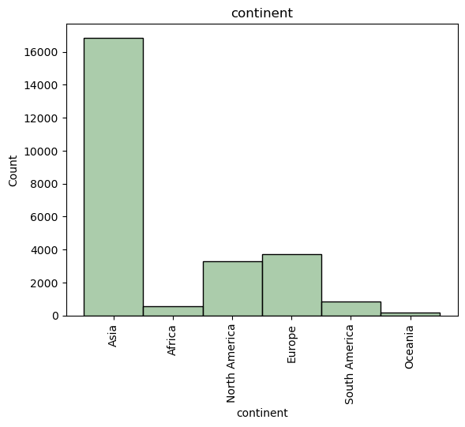

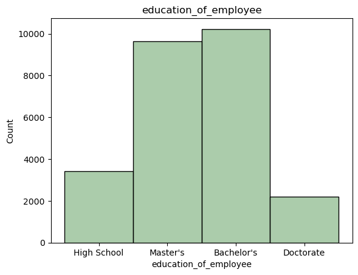

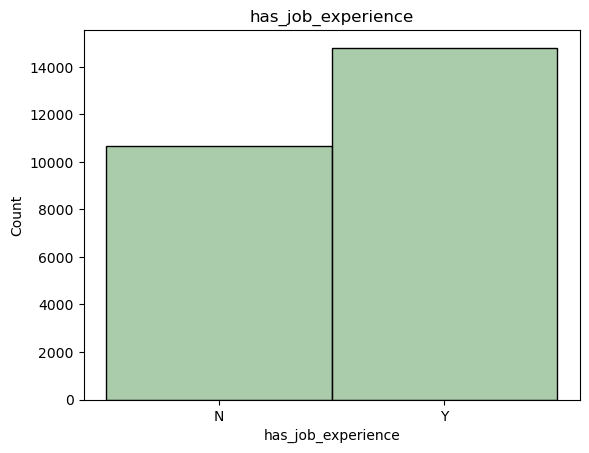

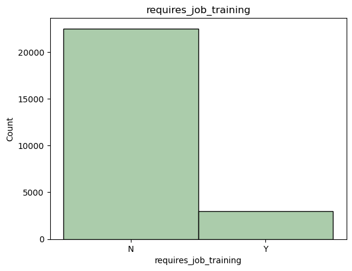

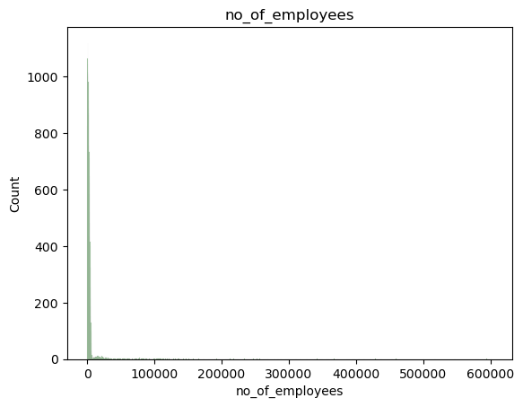

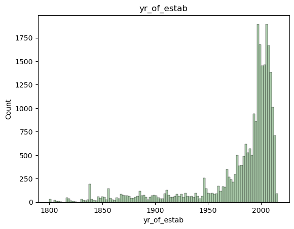

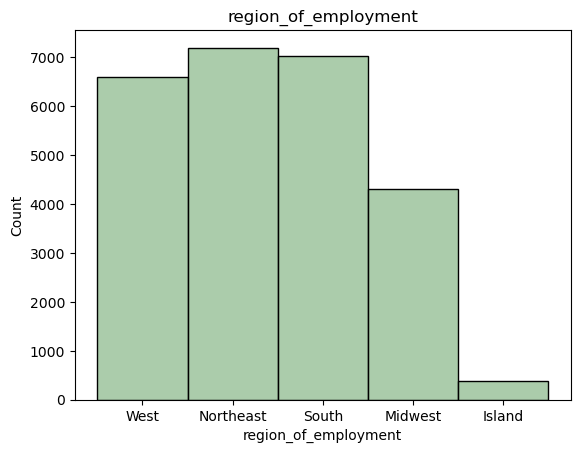

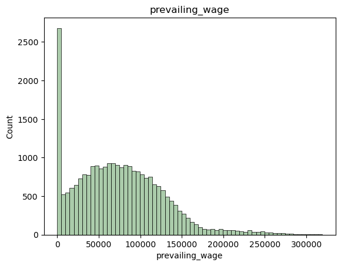

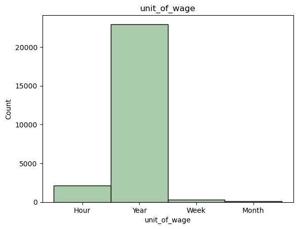

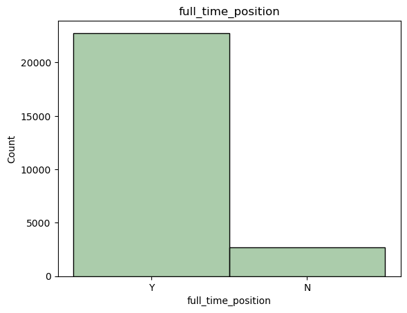

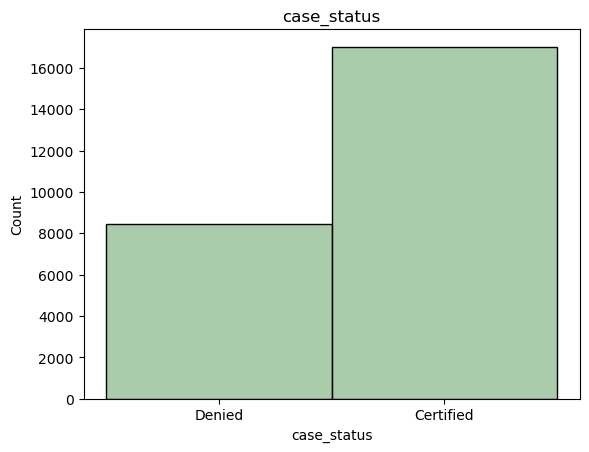

```python
#histogram for each column in visa
#all histograms use data from visa dataframe and the color is set to darkseagreen
for i in visa.columns: #for all columns in visa
    if (i=='case_id'): #if column is case_id
        pass #skip the column
    elif (i=='continent'): #if the column is continent
        sns.histplot(data=visa, x=i, color='darkseagreen') #make histogram with the column on the x-axis
        plt.title(i) #title is set to column name
        plt.xticks(rotation=90) #x-axis labels are rotated 90 degrees
        plt.show(); #display histogram
    else: #for all other columns
        sns.histplot(data=visa, x=i, color='darkseagreen') #make histogram with the column on x-axis
        plt.title(i) #title is set to column name
        plt.show(); #display histogram
```

#### Observations:

- Most of the employees are from Asia.
- There are many employees who have a Bachelor's degree or Master's degree. A small proportion of the employees completed high school. The education level with the least number of employees is Doctorate.
- There are more employees that have job experience.
- Most of the employees do not require job training.
- Most of the employers have less than 50,000 employees. The data for number of employees seems to be skewed to the right.
- Most of the employer's companies have been established later around the late 1900's and 2000's. There are only a few that have been established in the 1800's and early 1900's.The data for year of establishment is skewed to the left.
- The most popular intended regions of employment are Northeast, South, and West. The least popular region is Island.
- There are more employees that have a prevailing wage of 0. After that, there are more employees that have a prevailing wage between around 50,000 to 125,000. The data for prevailing wage is skewed to the right.
- The unit of wage for most employees is yearly.
- The position of work for most employees is full-time.
- There are around 8,000 denied cases, and around 16,000 certified cases. The visa was certified for most employees.

### Bivariate Analysis

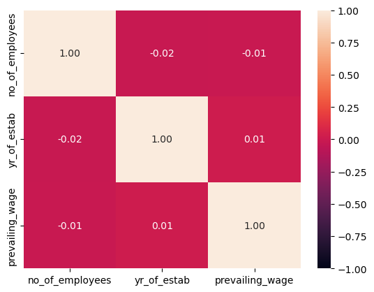

```python
#visa_num is assigned to only numerical columns in visa
visa_num = visa.select_dtypes(np.number)

#creating heatmap using visa_num columns to view correlation
#labels are shown/have 2 decimal spaces
#range is from -1 to 1
sns.heatmap(visa_num.corr(), annot=True, vmin=-1, vmax=1, fmt='.2f')
```

#### Observations:

There is no correlation between the numerical columns in visa.

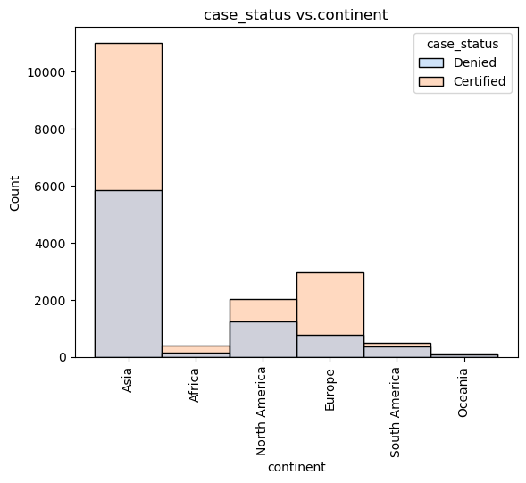

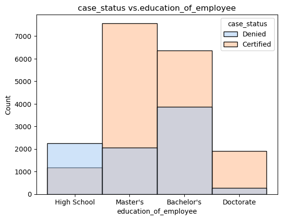

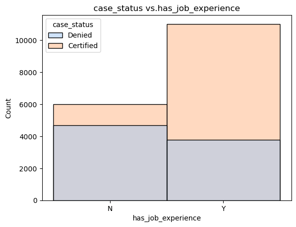

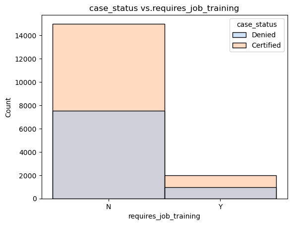

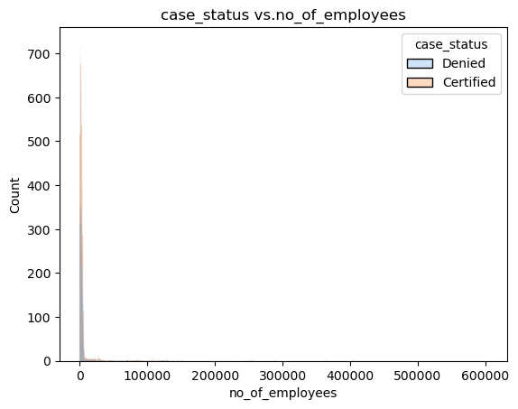

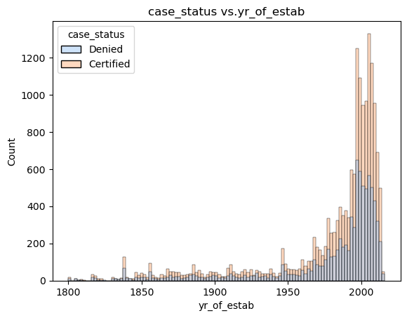

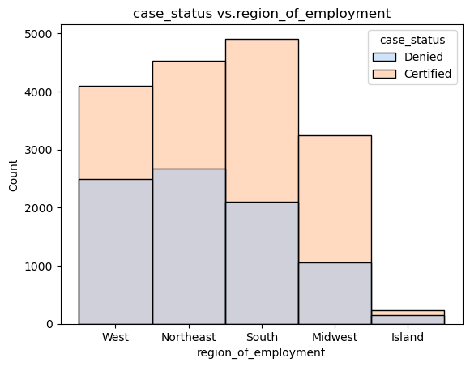

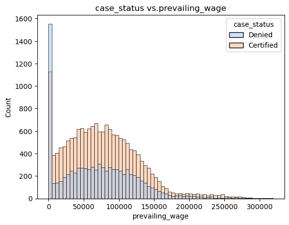

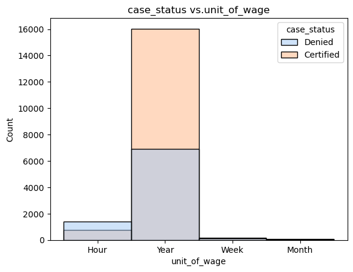

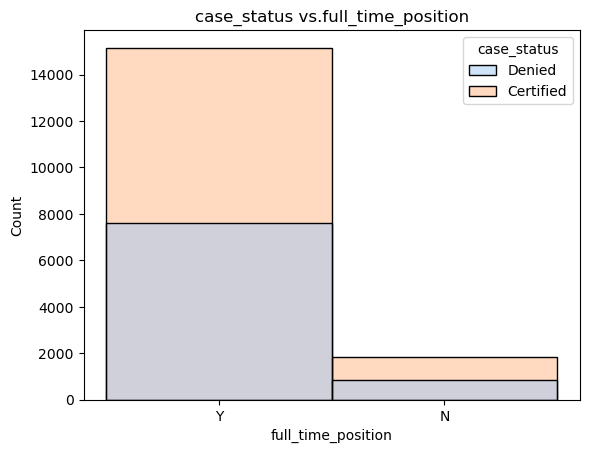

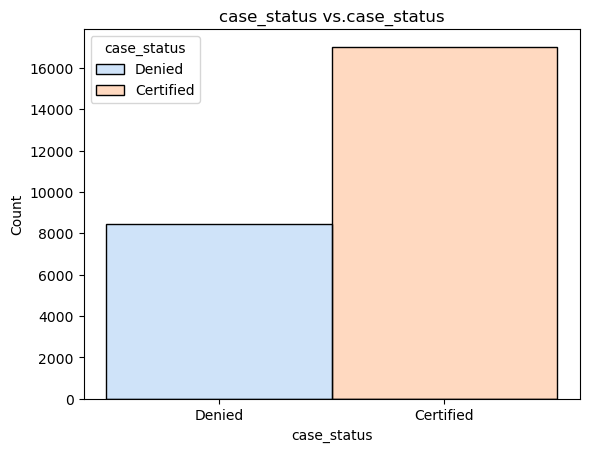

```python
#histogram for each column and its relationship with case_status column in visa
#all histograms use data from visa dataframe and the color palette is set to use pastel colors
for i in visa.columns: #for all columns in visa
    if (i=='case_id'): #if the column is case_id
        pass #skip the column
    elif (i=='continent'): #if the column is continent
        sns.histplot(data=visa, x=i, hue='case_status', palette='pastel') #make histogram with the column on the x-axis/hue is case_status
        plt.title('case_status vs.' + i) #setting title
        plt.xticks(rotation=90) #x-axis labels are rotated 90 degrees
        plt.show(); #display histogram
    else: #for all other columns
        sns.histplot(data=visa, x=i, hue='case_status', palette='pastel') #make histogram with the column on x-axis/hue is case_status
        plt.title('case_status vs.' + i) #setting title
        plt.show(); #display histogram
```

#### Observations:

- Compared to other continents, the visa status for a higher proportion of employees from South America and Oceania is denied.
- For employees with an education level of high school, the visa status for most employees is Denied.
- For employees with an education level of Master's, Bachelor's or Doctorate, the visa status for most employees is Certified.
- The visa status for a higher proportion of employees who have job experience is Certified, compared to those who have no job experience.
- For employees who have a prevailing wage of 0, the visa status for most employees is Denied. For employees with a prevailing wage greater than 0, the visa status for most employees is Certified.
- For employees who have Hour as their unit of wage, the visa status for most employees is Denied. For employees who have Year as their unit age, the visa status for most employees is Certified.

### Questions

**1) Those with higher education may want to travel abroad for a well-paid job. Does education play a role in Visa certification?**

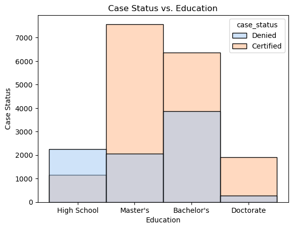

```python
#histogram for case_status vs. education_of_employee
#data from visa dataframe is used/ color palette is set to pastel colors
sns.histplot(data=visa, x='education_of_employee', hue='case_status', palette='pastel') #plotting education on x-axis/setting case_status as hue
plt.title('Case Status vs. Education') #setting title of histogram
plt.xlabel('Education') #setting title of x-axis
plt.ylabel('Case Status') #setting title of y-axis
plt.show(); #displaying histogram
```

#### Observations:

- Case status seems to vary for different education levels, which indicates that education might play a role in case status, but to what extent education affects case status needs to be further analyzed in the models.
- For employees who have an education level of High School, there are more Denied cases than Certified cases.
- For employees who have an education level of Master's, Bachelor's, or Doctorate, there are more Certified cases than Denied cases.
- As the education level increases from Bachelor's to Doctorate, the proportion of cases that are Certified seems to increase, and the proportion of cases that are Denied seems to decrease.

**2) How does visa status vary across different continents?**

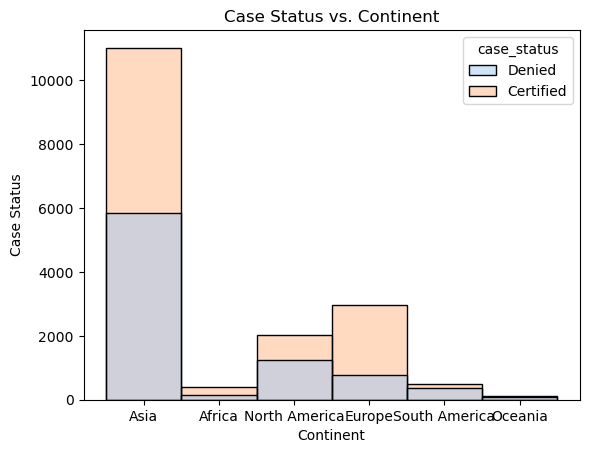

```python
#histogram for case_status vs. continent
#data from visa dataframe is used/ color palette is set to pastel colors
sns.histplot(data=visa, x='continent', hue='case_status', palette='pastel') #plotting continent on x-axis/setting case_status as hue
plt.title('Case Status vs. Continent') #setting title of histogram
plt.xlabel('Continent') #setting title of x-axis
plt.ylabel('Case Status') #setting title of y-axis
plt.show(); #displaying histogram
```

#### Observations:

- Most employees are from Asia.
- For Asia, Africa, North America, Europe and South America, there are more employees who are Certified than Denied.
- For Oceania, there seems to be an almost equal proportion of Denied and Certified cases.
- Compared to the other continents, a larger proportion of employees in Europe seem to be Certified.

**3) Experienced professionals might look abroad for opportunities to improve their lifestyles and career development. Does work experience influence visa status?**

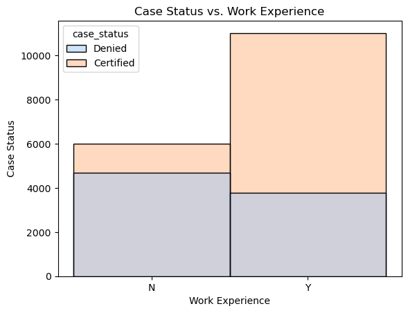

```python
#histogram for case_status vs. has_job_experience
#data from visa dataframe is used/ color palette is set to pastel colors
sns.histplot(data=visa, x='has_job_experience', hue='case_status', palette='pastel') #plotting has_job_experience on x-axis/setting case_status as hue
plt.title('Case Status vs. Work Experience') #setting title of histogram
plt.xlabel('Work Experience') #setting title of x-axis
plt.ylabel('Case Status') #setting title of y-axis
plt.show(); #displaying histogram
```

#### Observations:

- There is a chance that work experience might affect visa status because a higher proportion of employees who have work experience are Certified.
- For employees with no work experience, the proportion of employees that are Certified is greater than the proportion of employees that are denied.
- However, there is a large proportion of employees with no work experience that are Denied, compared to the proportion of employees with work experience that are denied.

**4) In the United States, employees are paid at different intervals. Which pay unit is most likely to be certified for a visa?**

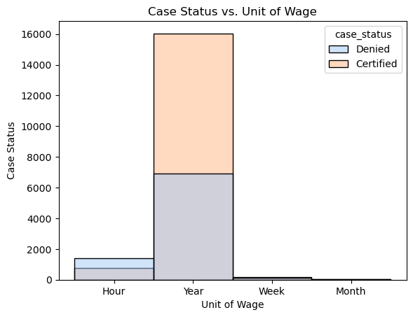

```python
#histogram for case_status vs. unit_of_wage
#data from visa dataframe is used/ color palette is set to pastel colors
sns.histplot(data=visa, x='unit_of_wage', hue='case_status', palette='pastel') #plotting unit_of_wage on x-axis/setting case_status as hue
plt.title('Case Status vs. Unit of Wage') #setting title of histogram
plt.xlabel('Unit of Wage') #setting title of x-axis
plt.ylabel('Case Status') #setting title of y-axis
plt.show(); #displaying histogram
```

#### Observations:

- Compared to the other units of wage, yearly wage seems most likely to be certified for a visa.
- For hourly wage, there are more cases that are Denied than Certified.
- For weekly wage and monthly wage, there seem to be an equal proportion of Denied cases as Certified cases.
- For yearly wage, there is a much greater proportion of cases that are Certified than Denied.

**5) The US government has established a prevailing wage to protect local talent and foreign workers. How does the visa status change with the prevailing wage?**

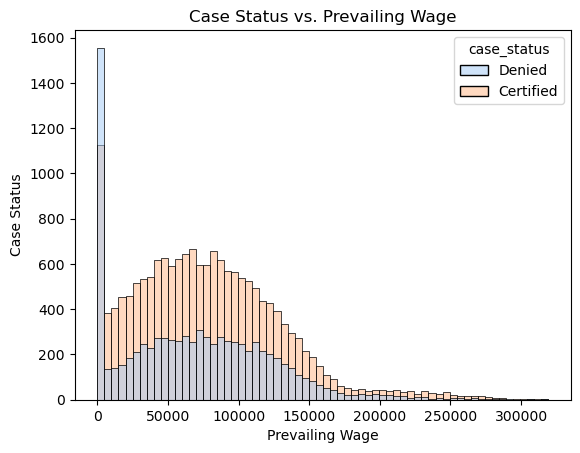

```python
#histogram for case_status vs. prevailing_wage
#data from visa dataframe is used/ color palette is set to pastel colors
sns.histplot(data=visa, x='prevailing_wage', hue='case_status', palette='pastel') #plotting prevailing_wage on x-axis/setting case_status as hue
plt.title('Case Status vs. Prevailing Wage') #setting title of histogram
plt.xlabel('Prevailing Wage') #setting title of x-axis
plt.ylabel('Case Status') #setting title of y-axis
plt.show(); #displaying histogram
```

#### Observations:

- For employees who have a prevailing wage of 0, there are more cases that are Denied than Certified.
- For employees with a prevailing wage greater than 0, there are more cases that are Certified than Denied.
- This seems to indicate that a prevailing wage of 0 might possibly have a higher chance of being Denied.

## Data Preprocessing

### Missing Value Treatment

```python
#making sure there are no null values in visa
visa.isnull().sum()
```

```
case_id                  0
continent                0
education_of_employee    0
has_job_experience       0
requires_job_training    0
no_of_employees          0
yr_of_estab              0
region_of_employment     0
prevailing_wage          0
unit_of_wage             0
full_time_position       0
case_status              0
dtype: int64
```

#### Observations:

There are no missing values.

### Feature Engineering

```python
#dropping case_id column from visa
visa = visa.drop(['case_id'], axis=1)
```

#### Observations:

The case_id column will not add much to the analysis because every value in the column is unique. The purpose of this column is only for identification of cases.

### Outlier Detection and Treatment

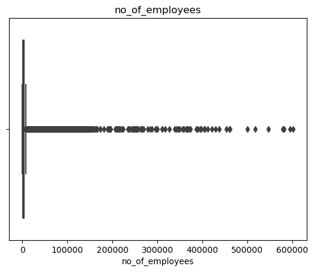

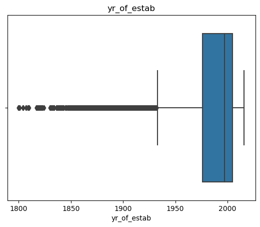

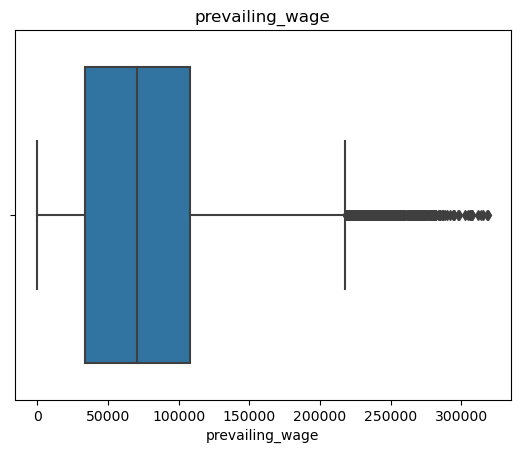

```python
#reassigning visa_num variable to numerical columns in visa
visa_num = visa.select_dtypes(np.number)

#creating boxplot using data in visa_num
for i in visa_num.columns: #for each column in visa_num
    sns.boxplot(data=visa, x=i) #plot the column in x-axis
    plt.title(i) #set title to column name
    plt.show(); #display boxplot
```

#### Observations:

- There are many outliers in these columns, however they represent important data. It is best to keep them as they are.

### Preparing Data for Modeling

```python
#replacing case_status values of Certified with 1, and Denied with 0
visa['case_status'] = visa['case_status'].apply(lambda x: 1 if x == 'Certified' else 0)
```

```python
#viewing values of case_status
visa['case_status'].value_counts()
```

```
1    17018
0     8462
Name: case_status, dtype: int64
```

#### Observations:

The values of case_status have been changed to 0 and 1.

```python
#adding all columns, excluding case_status, to X
X = visa.drop(['case_status'], axis=1)
#adding case_status to Y
Y = visa['case_status']
```

```python
#making dummy variables in X and dropping first dummy variable in each set
X = pd.get_dummies(X, drop_first=True)
```

```python
#checking the variables in X
X.count()
```

```
no_of_employees                      25480
yr_of_estab                          25480
prevailing_wage                      25480
continent_Asia                       25480
continent_Europe                     25480
continent_North America              25480
continent_Oceania                    25480
continent_South America              25480
education_of_employee_Doctorate      25480
education_of_employee_High School    25480
education_of_employee_Master's       25480
has_job_experience_Y                 25480
requires_job_training_Y              25480
region_of_employment_Midwest         25480
region_of_employment_Northeast       25480
region_of_employment_South           25480
region_of_employment_West            25480
unit_of_wage_Month                   25480
unit_of_wage_Week                    25480
unit_of_wage_Year                    25480
full_time_position_Y                 25480
dtype: int64
```

```python
#splitting X and Y into train and test groups with a train to test ratio of 70:30
X_train, X_test, y_train, y_test = train_test_split(X, Y, test_size=0.3, random_state=1, stratify=Y)
```

```python
#printing frequency of values in y_train and y_test/printing number of rows/columns in X_test and X_train
print('y_train:\n', y_train.value_counts(normalize=True))
print('y_test:\n', y_test.value_counts(normalize=True))
print('X_train:\n', X_train.shape)
print('X_test:\n', X_test.shape)
```

```
y_train:
 1    0.667919
0    0.332081
Name: case_status, dtype: float64
y_test:
 1    0.667844
0    0.332156
Name: case_status, dtype: float64
X_train:
 (17836, 21)
X_test:
 (7644, 21)
```

#### Observations:

- The data has been split into X and Y, with case_status in Y and all other columns in X.
- Dummy variables have been created, and the data has the been split into train and test groups with 70:30 ratio.
- The frequency of values in y_train and y_test are the same.